# Your 2017-18 NBA Candidates

December 13, 2017

## Introduction

-Analyzed the current NBA season to try to predict the 2017-18 MVP

-Data imported through BBR (basketball reference) package

-Formula includes: Points, Rebounds, Assists, Steals, Blocks, Turnovers, and Shooting Percentage

## Code used for Calculations

playerRankings <- transmute(year, player, tm, pos, PointsRank=(((pts/g)/20)*.325), ReboundsRank=(((trb/g)/10)*.2), AssistsRank=(((ast/g)/5)*.2), StealsRank=(((stl/g)/1.5)*.1), BlocksRank=(((blk/g)/1)*.1), TurnoversRank=(((tov/g)/3)*.1), PctRank=(((fg_pct)/.5)*.075)

## Points

-Based off 20

-Weighted at 32.5%

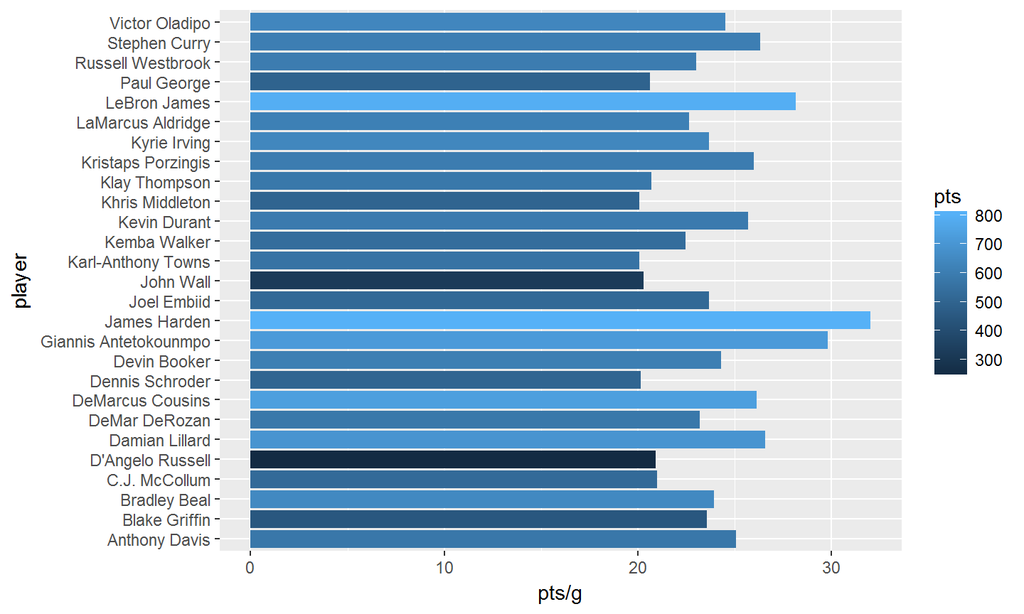

## Rebounds

-Based off 10

-Weighted at 20%

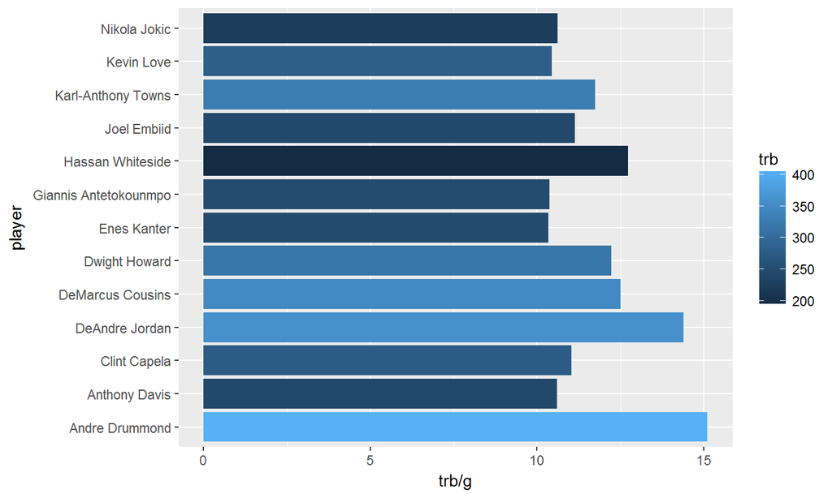

## Assists

-Based off 5

-Weighted at 20%

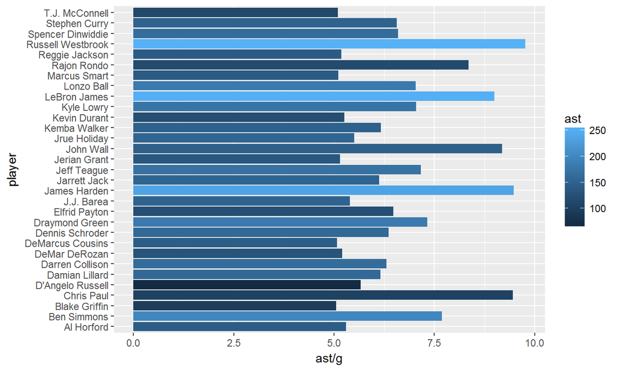

## Steals

-Based off 1.5

-Weighted at 10%

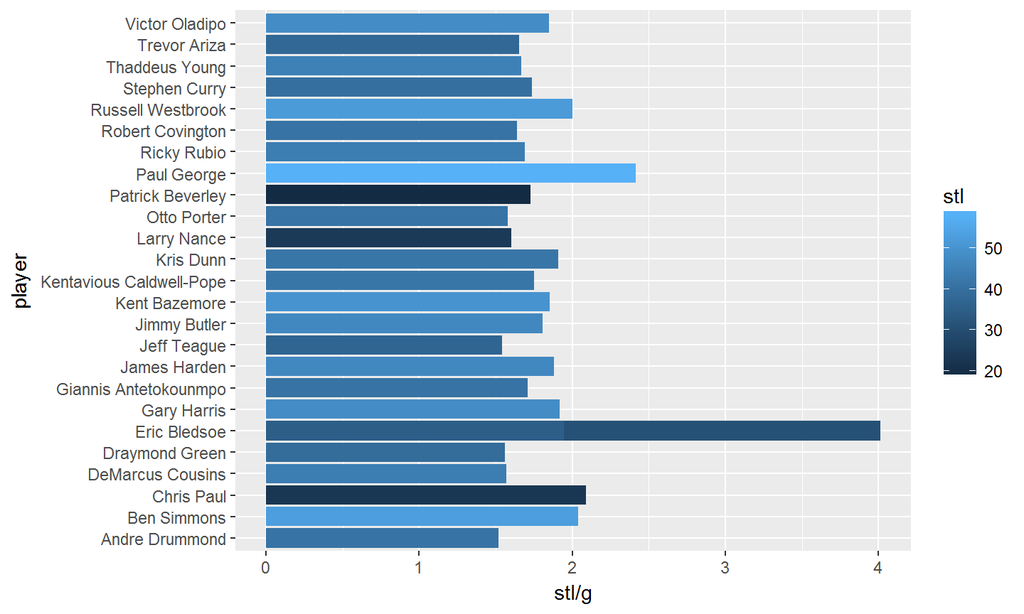

## Blocks

-Weighted at 10%

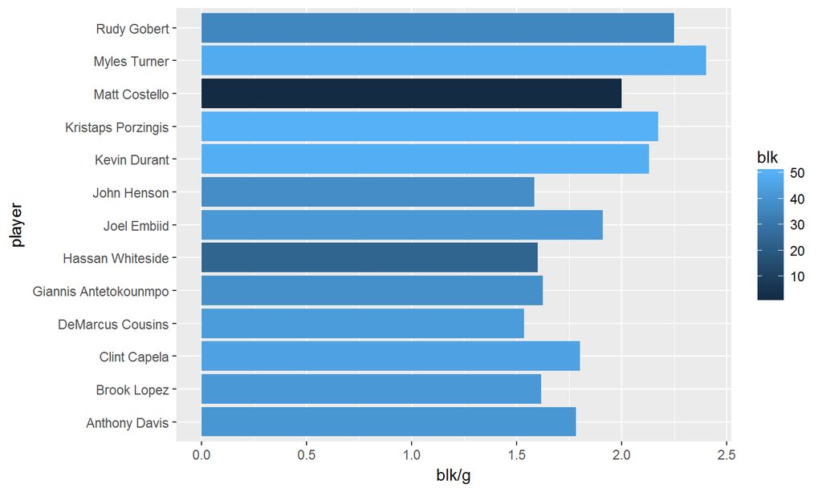

## Additional Stats

-Turnovers based off 3, weighted at -10%

-FG shooting % based off 50%, weighted at 7.5%

## Top 5 Table

Overall Rankings

| player | tm | pos | OverallRank |
| --- | --- | --- | --- |
| LeBron James | CLE | PF | 1.1398756 |
| Giannis Antetokounmpo | MIL | PF | 1.1319694 |
| James Harden | HOU | SG | 1.0917000 |
| DeMarcus Cousins | NOP | C | 1.0405857 |
| Russell Westbrook | OKC | PG | 0.9932622 |

## Graph of Top 5

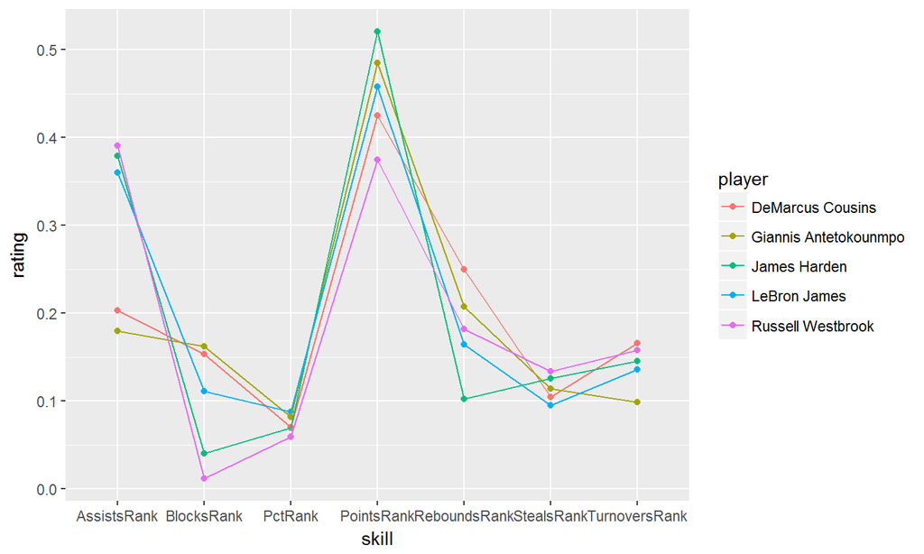

## Verification for last 5 years

-2013: Actual Winner: Lebron James, My winner: LeBron James

-2014: Actual Winner: Kevin Durant, My winner: Kevin Durant

-2015: Actual Winner: Stephen Curry(7), My winner: Anthony Davis(5)

-2016: Actual Winner: Stephen Curry(2), My winner: Russell Westbrook(4)

-2017: Actual Winner: Russell Westbrook, My winner: Russell Westbrook

## Things not factored

-Team Results

-+/-

-Games Played

-Team Changes compounding stats in database